# Airport Stock Prediction by Latency

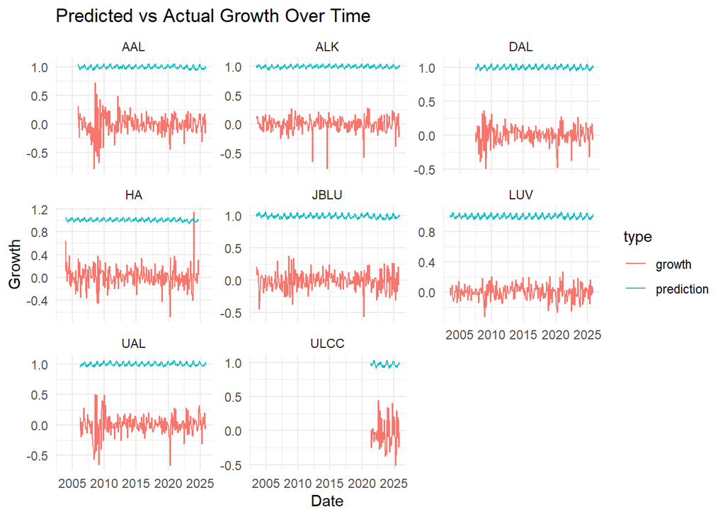

```r
pred_simple <- tibble::tibble(
  prediction = exp(fitted(glm_stock_simple)),
  growth     = model.response(model.frame(glm_stock_simple)),
  Carrier    = model.frame(glm_stock_simple)$carrier,
  Date       = glm_stock_simple$data$S_Date
) |>
  mutate(
    pred_delta = growth - prediction
  )

pred_simple |>
  pivot_longer(cols = c(prediction, growth),
               names_to = "type",
               values_to = "value")%>%
ggplot(aes(x = Date, y = value, color = type)) +
  geom_line() +
  facet_wrap(~ Carrier, scales = "free_y") +
  labs(
    title = "Predicted vs Actual Growth Over Time",
    x = "Date",
    y = "Growth"
  ) +
  theme_minimal()
```

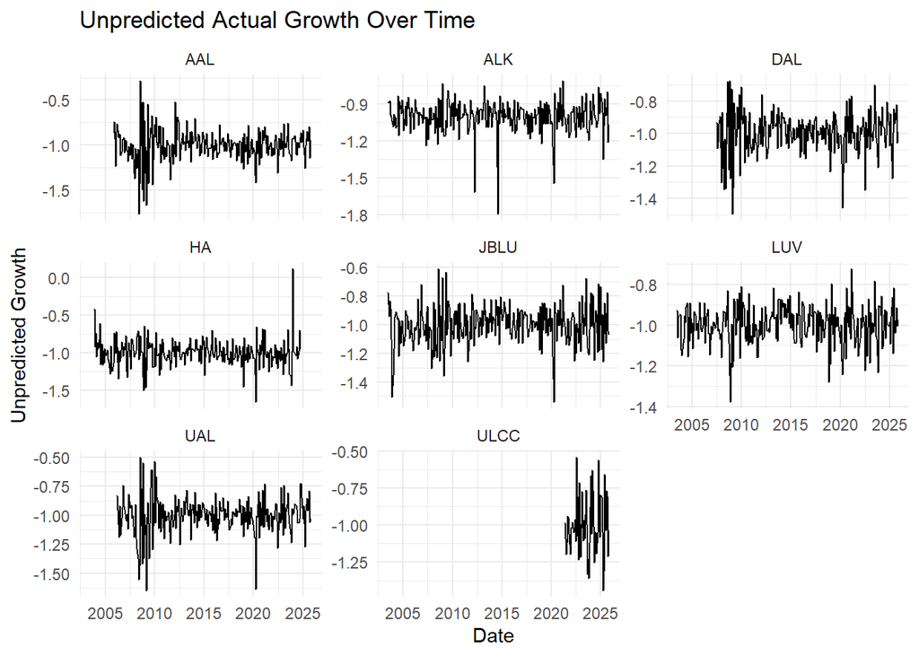

```r
pred_simple |>
ggplot(aes(x = Date, y = pred_delta)) +
  geom_line() +
  facet_wrap(~ Carrier, scales = "free_y") +
  labs(
    title = "Unpredicted Actual Growth Over Time",
    x = "Date",
    y = "Unpredicted Growth"
  ) +
  theme_minimal()
```

## Main Model’s Stability Test

```r
lmtest::bptest(glm_stock_simple)
```

```
##
##  studentized Breusch-Pagan test
##
## data:  glm_stock_simple
## BP = 63.009, df = 19, p-value = 1.281e-06
```

A Breusch-Pagan test strongly rejected the null hypothesis of homoskedasticity (BP = 63.01, p < 0.001), indicating the presence of heteroskedasticity. Therefore, heteroskedasticity-robust standard errors were employed in all subsequent regression.

```r
car::vif(glm_stock_simple)
```

```
##                   GVIF Df GVIF^(1/(2*Df))
## av_delay      2.048449  1        1.431240
## factor(month) 1.213267 11        1.008826
## carrier       1.835900  7        1.044351
```

Robustness Checks

To verify the validity of the empirical results, several robustness checks were conducted. A Breusch–Pagan test indicated the presence of heteroskedasticity; therefore, all models were estimated using heteroskedasticity-robust standard errors. In addition, given the panel structure of the data (airlines observed over time), standard errors were clustered at the airline level to account for potential within-firm serial correlation.

### Fix Main Model

Pooled OLS may confound cross-sectional differences with within-firm effects; therefore a fixed-effects estimator is employed.

```r
model_stock_fixest <- feols(
  log(grow_log) ~ av_delay | carrier + month,
  data = av_delay_df,
  cluster = ~ carrier
)

summary(model_stock_fixest)
```

```
## OLS estimation, Dep. Var.: log(grow_log)
## Observations: 1,809
## Fixed-effects: carrier: 8,  month: 12
## Standard-errors: Clustered (carrier)
##           Estimate Std. Error  t value Pr(>|t|)
## av_delay -0.002057   0.000564 -3.64778 0.008202 **
## ---
## Signif. codes:  0 '***' 0.001 '**' 0.01 '*' 0.05 '.' 0.1 ' ' 1
## RMSE: 0.145832     Adj. R2: 0.022638
##                  Within R2: 0.003733
```

## Alternative Models

### Fuel Effect

```r
model_fuel_fixest <- feols(
  log(grow_log) ~ av_delay + fuel_del| carrier + month,
  data = av_delay_df,
  cluster = ~ carrier
)

summary(model_fuel_fixest)
```

```
## OLS estimation, Dep. Var.: log(grow_log)
## Observations: 1,809
## Fixed-effects: carrier: 8,  month: 12
## Standard-errors: Clustered (carrier)
##           Estimate Std. Error   t value  Pr(>|t|)
## av_delay -0.002058   0.000568 -3.626450 0.0084375 **
## fuel_del -0.004181   0.031164 -0.134152 0.8970581
## ---
## Signif. codes:  0 '***' 0.001 '**' 0.01 '*' 0.05 '.' 0.1 ' ' 1
## RMSE: 0.145831     Adj. R2: 0.022099
##                  Within R2: 0.00374
```

### On Time Instead of Late

```r
av_delay_df_on_time<-
  delay_data %>%
  select(airport,carrier,year, month, arr_delay, arr_flights, arr_del15, arr_cancelled, arr_diverted) %>%
  group_by(carrier, year, month) %>%
  summarise(
    arr_flights = sum(arr_flights, na.rm = TRUE),
    not_on_time = sum(arr_del15+ arr_cancelled +    arr_diverted, na.rm = TRUE),
    .groups = "drop"
  ) %>%
  mutate(on_time_pr= (arr_flights-not_on_time)/arr_flights) %>%
  left_join(all_stock, join_by(carrier== Carrier, year== year, month== month), relationship = "many-to-many") %>%
  filter(S_Date>= "2002-01-01" & S_Date<= "2025-11-01") %>%
  mutate(grow= (close-open)/open,
         grow_log= close/open,
         post_corona= (year>= 2020 & month>= 3) | year>= 2021,
         decade= (year-2000) %/% 10)
```

```r
model_on_time_fixest <- feols(
  log(grow_log) ~ on_time_pr | carrier + month,
  data = av_delay_df_on_time,
  cluster = ~ carrier
)

summary(model_on_time_fixest)
```

```
## OLS estimation, Dep. Var.: log(grow_log)
## Observations: 1,809
## Fixed-effects: carrier: 8,  month: 12
## Standard-errors: Clustered (carrier)
##            Estimate Std. Error t value  Pr(>|t|)
## on_time_pr 0.205751   0.046146 4.45872 0.0029406 **
## ---
## Signif. codes:  0 '***' 0.001 '**' 0.01 '*' 0.05 '.' 0.1 ' ' 1
## RMSE: 0.145493     Adj. R2: 0.027177
##                  Within R2: 0.00836
```

### Add Year Effect

```r
model_stock_fixest_ym <- feols(
  log(grow_log) ~ av_delay | carrier + month+ year,
  data = av_delay_df,
  cluster = ~ carrier
)

summary(model_stock_fixest_ym)
```

```
## OLS estimation, Dep. Var.: log(grow_log)
## Observations: 1,809
## Fixed-effects: carrier: 8,  month: 12,  year: 23
## Standard-errors: Clustered (carrier)
##           Estimate Std. Error  t value Pr(>|t|)
## av_delay -0.002723   0.001027 -2.65232 0.032831 *
## ---
## Signif. codes:  0 '***' 0.001 '**' 0.01 '*' 0.05 '.' 0.1 ' ' 1
## RMSE: 0.143697     Adj. R2: 0.039229
##                  Within R2: 0.0047
```

### Lag Model

```r
lag_data <- av_delay_df %>%
  arrange(carrier, S_Date) %>%
  group_by(carrier) %>%
  mutate(
    delay_lag1 = lag(av_delay, 1),
    delay_lag2 = lag(av_delay, 2),
    delay_lag3 = lag(av_delay, 3)
  ) %>%
  ungroup() %>%
  drop_na(delay_lag1, delay_lag2, delay_lag3)

lag_on_time <- av_delay_df_on_time %>%
  arrange(carrier, S_Date) %>%
  group_by(carrier) %>%
  mutate(
    time_lag1 = lag(on_time_pr, 1),
    time_lag2 = lag(on_time_pr, 2),
    time_lag3 = lag(on_time_pr, 3)
  ) %>%
  ungroup() %>%
  drop_na(time_lag1, time_lag2, time_lag3)


model_stock_lag3 <- feols(
  log(grow_log) ~ av_delay + delay_lag1 + delay_lag2 + delay_lag3|
                  month + carrier,
  data   = lag_data,
  cluster = ~ carrier
)

summary(model_stock_lag3)
```

```
## OLS estimation, Dep. Var.: log(grow_log)
## Observations: 1,785
## Fixed-effects: month: 12,  carrier: 8
## Standard-errors: Clustered (carrier)
##             Estimate Std. Error   t value Pr(>|t|)
## av_delay   -0.000718   0.001463 -0.490731  0.63863
## delay_lag1 -0.000172   0.001294 -0.133117  0.89785
## delay_lag2 -0.000159   0.000929 -0.171218  0.86890
## delay_lag3 -0.002298   0.000947 -2.426414  0.04566 *
## ---
## Signif. codes:  0 '***' 0.001 '**' 0.01 '*' 0.05 '.' 0.1 ' ' 1
## RMSE: 0.144967     Adj. R2: 0.022721
##                  Within R2: 0.007539
```

## Compare all models

```r
models<- list(model_stock_fixest,model_fuel_fixest,model_on_time_fixest,model_stock_fixest_ym,model_stock_lag3)
names(models)<-   c("fixest_C_M", "fixest_C_M+Fuel", "fixest_C_M on time", "fixest_C_M_Y", "fixest_C_M lag3")
modelsummary::modelsummary(models, title = "model 2-6 values")
```

model 2-6 values

|  | fixest_C_M | fixest_C_M+Fuel | fixest_C_M on time | fixest_C_M_Y | fixest_C_M lag3 |
| --- | --- | --- | --- | --- | --- |
| av_delay | -0.002 | -0.002 |  | -0.003 | -0.001 |
|  | (0.001) | (0.001) |  | (0.001) | (0.001) |
| fuel_del |  | -0.004 |  |  |  |
|  |  | (0.031) |  |  |  |
| on_time_pr |  |  | 0.206 |  |  |
|  |  |  | (0.046) |  |  |
| delay_lag1 |  |  |  |  | -0.000 |
|  |  |  |  |  | (0.001) |
| delay_lag2 |  |  |  |  | -0.000 |
|  |  |  |  |  | (0.001) |
| delay_lag3 |  |  |  |  | -0.002 |
|  |  |  |  |  | (0.001) |
| Num.Obs. | 1809 | 1809 | 1809 | 1809 | 1785 |
| R2 | 0.033 | 0.033 | 0.037 | 0.061 | 0.035 |
| R2 Adj. | 0.023 | 0.022 | 0.027 | 0.039 | 0.023 |
| R2 Within | 0.004 | 0.004 | 0.008 | 0.005 | 0.008 |
| R2 Within Adj. | 0.003 | 0.003 | 0.008 | 0.004 | 0.005 |
| AIC | -1792.0 | -1790.0 | -1800.4 | -1801.4 | -1783.0 |
| BIC | -1682.0 | -1674.5 | -1690.4 | -1570.4 | -1656.8 |
| RMSE | 0.15 | 0.15 | 0.15 | 0.14 | 0.14 |
| FE: carrier | X | X | X | X | X |
| FE: month | X | X | X | X | X |
| FE: year |  |  |  | X |  |

first, lets compare the models with a filtered data, that omit the first 3 rows of each carrier in order to compare equal observation comparing .

```r
model_stock_fixest_rl  <- feols(log(grow_log) ~ av_delay | carrier + month,
                                data = lag_data, cluster = ~carrier)

model_fuel_fixest_rl    <- feols(
  log(grow_log) ~ av_delay + fuel_del| carrier + month,
  data = lag_data,
  cluster = ~ carrier
)

model_on_time_fixest_rl <- feols( log(grow_log) ~ on_time_pr | carrier + month,
  data = lag_on_time, cluster = ~ carrier)

model_stock_fixest_ym_rl <- feols(
  log(grow_log) ~ av_delay | carrier + month+ year,
  data = lag_data,
  cluster = ~ carrier
)
```

```r
models<- list(model_stock_fixest_rl,model_fuel_fixest_rl,model_on_time_fixest_rl,model_stock_fixest_ym_rl,model_stock_lag3)
names(models)<-   c("fixest_C_M", "fixest_C_M+Fuel", "fixest_C_M on time", "fixest_C_M_Y", "fixest_C_M lag3")
cat("\n--- Model Comparison (equal sample) ---\n")
```

```
##
## --- Model Comparison (equal sample) ---
```

```r
modelsummary::modelsummary(models, title = "models 2-6 lag compare")
```

models 2-6 lag compare

|  | fixest_C_M | fixest_C_M+Fuel | fixest_C_M on time | fixest_C_M_Y | fixest_C_M lag3 |
| --- | --- | --- | --- | --- | --- |
| av_delay | -0.002 | -0.002 |  | -0.003 | -0.001 |
|  | (0.001) | (0.001) |  | (0.001) | (0.001) |
| fuel_del |  | -0.005 |  |  |  |
|  |  | (0.030) |  |  |  |
| on_time_pr |  |  | 0.200 |  |  |
|  |  |  | (0.050) |  |  |
| delay_lag1 |  |  |  |  | -0.000 |
|  |  |  |  |  | (0.001) |
| delay_lag2 |  |  |  |  | -0.000 |
|  |  |  |  |  | (0.001) |
| delay_lag3 |  |  |  |  | -0.002 |
|  |  |  |  |  | (0.001) |
| Num.Obs. | 1785 | 1785 | 1785 | 1785 | 1785 |
| R2 | 0.031 | 0.031 | 0.035 | 0.062 | 0.035 |
| R2 Adj. | 0.020 | 0.020 | 0.025 | 0.040 | 0.023 |
| R2 Within | 0.003 | 0.003 | 0.008 | 0.005 | 0.008 |
| R2 Within Adj. | 0.003 | 0.002 | 0.007 | 0.004 | 0.005 |
| AIC | -1781.1 | -1779.1 | -1789.5 | -1795.4 | -1783.0 |
| BIC | -1671.4 | -1663.9 | -1679.8 | -1565.0 | -1656.8 |
| RMSE | 0.15 | 0.15 | 0.14 | 0.14 | 0.14 |
| FE: carrier | X | X | X | X | X |
| FE: month | X | X | X | X | X |
| FE: year |  |  |  | X |  |

Using the $AIC$ model, the Fixed effect model by carrier, year and month looks to be the better one.

the final model (without lag obsservation omiting)

```r
summary(model_stock_fixest_ym)
```

```
## OLS estimation, Dep. Var.: log(grow_log)
## Observations: 1,809
## Fixed-effects: carrier: 8,  month: 12,  year: 23
## Standard-errors: Clustered (carrier)
##           Estimate Std. Error  t value Pr(>|t|)
## av_delay -0.002723   0.001027 -2.65232 0.032831 *
## ---
## Signif. codes:  0 '***' 0.001 '**' 0.01 '*' 0.05 '.' 0.1 ' ' 1
## RMSE: 0.143697     Adj. R2: 0.039229
##                  Within R2: 0.0047
```